# Mapa Mimulus - LG3

Cristiane Taniguti, Fernando Correr, Fernando Espolador, Johnathan Pedroso

Maio de 2017

Avaliação individual do grupo 3 formado a partir dos marcadores contidos [neste arquivo](https://cristianetaniguti.github.io/htmls/mapa_mimulus/data_with_head.raw). Para mais informações acesse a [página principal](https://cristianetaniguti.github.io/htmls/mapa_mimulus/mapa_mimulus.html).

# 1 Carregando dados gerados na pagina principal

```r
load("LGs_force_HMM_Markers_First_Check.RData")
load("LGs_safe_HMM_Markers_First_Check.RData")


library(onemap)
data1 <- read_mapmaker(file = "data_with_head.raw")
LOD <- suggest_lod(data1)
rf2points <- rf_2pts(data1, LOD = LOD, max.rf = 0.5)
```

# 2 Comparando “safe” e “force”

```r
#Marcadores presentes no "force" e ausentes no "safe" de HMM
comp_unsafe <- LGs.HMM.force[[3]]$seq.num %in% LGs.HMM.safe[[3]]$seq.num
pos_unsafe <- which(comp_unsafe == FALSE)
unsafe <- LGs.HMM.force[[3]]$seq.num[pos_unsafe]
unsafe
```

```
##  [1] 319 280 278 210  65 151 177 212 126 147 313  38  64 305 293 129   7
## [18] 109 149 106 102  98 346 284 114 138 261 306  52  85 323 336 300 282
## [35] 122  63 157 153 171  75 174  94 263 292 309 314 257 329 158 194 108
## [52] 105 195 119   3 205  92  30 228  48 110 312  79 211 120 272 351  82
## [69] 162
```

# 3 Breve comparação com o mapa publicado

Desde já podemos comparar os grupos formados com o mapa já publicado, para sabermos a correspondência entre ambos. Para facilitar, fizemos [esta tabela](https://cristianetaniguti.github.io/htmls/mapa_mimulus/LG.csv) com os nomes dos marcadores que compoem o mapa publicado, sendo que cada coluna da tabela corresponde à um grupo de ligação.

```r
ref <- read.csv(file = "LG.csv", stringsAsFactors = FALSE)
names <- colnames(data1$geno)[LGs.HMM.force[[3]]$seq.num]

comp <- pos <- lgs <- pos2 <- num_lgs <- list()
for (i in 1:length(ref)){
  comp[[i]] <- ref[[i]] %in% names
  pos[[i]] <- which(comp[[i]] == TRUE)
  lgs[[i]] <- ref[[i]][pos[[i]]]
  pos2[[i]] <- names %in% lgs[[i]]
  num_lgs[[i]] <- LGs.HMM.force[[3]]$seq.num[pos2[[i]]]
}

comp
```

```
## [[1]]
##  [1] FALSE FALSE FALSE FALSE FALSE FALSE FALSE FALSE FALSE FALSE FALSE
## [12] FALSE FALSE FALSE FALSE FALSE FALSE
##
## [[2]]
##  [1] FALSE FALSE FALSE FALSE FALSE FALSE FALSE FALSE FALSE FALSE FALSE
## [12] FALSE FALSE FALSE FALSE FALSE FALSE
##
## [[3]]
##  [1]  TRUE  TRUE  TRUE  TRUE  TRUE  TRUE  TRUE  TRUE  TRUE  TRUE FALSE
## [12]  TRUE FALSE FALSE FALSE FALSE FALSE
##
## [[4]]
##  [1] FALSE FALSE FALSE FALSE FALSE FALSE FALSE FALSE FALSE FALSE FALSE
## [12] FALSE FALSE FALSE FALSE FALSE FALSE
##
## [[5]]
##  [1] FALSE FALSE FALSE FALSE FALSE FALSE FALSE FALSE FALSE FALSE FALSE
## [12] FALSE FALSE FALSE FALSE FALSE FALSE
##
## [[6]]
##  [1] FALSE FALSE FALSE FALSE FALSE FALSE FALSE FALSE FALSE FALSE FALSE
## [12] FALSE FALSE FALSE FALSE FALSE FALSE
##
## [[7]]
##  [1]  TRUE FALSE  TRUE  TRUE FALSE  TRUE  TRUE  TRUE  TRUE FALSE FALSE
## [12] FALSE FALSE FALSE FALSE FALSE FALSE
##
## [[8]]
##  [1] FALSE FALSE FALSE FALSE FALSE FALSE FALSE FALSE FALSE FALSE FALSE
## [12] FALSE FALSE FALSE FALSE FALSE FALSE
##
## [[9]]
##  [1] FALSE FALSE FALSE FALSE FALSE FALSE FALSE FALSE FALSE FALSE FALSE
## [12] FALSE FALSE FALSE FALSE FALSE FALSE
##
## [[10]]
##  [1]  TRUE  TRUE  TRUE FALSE  TRUE  TRUE  TRUE  TRUE  TRUE  TRUE  TRUE
## [12]  TRUE  TRUE  TRUE  TRUE FALSE FALSE
##
## [[11]]
##  [1] FALSE FALSE FALSE FALSE FALSE FALSE FALSE FALSE FALSE FALSE FALSE
## [12] FALSE FALSE FALSE FALSE FALSE FALSE
##
## [[12]]
##  [1] FALSE FALSE FALSE FALSE FALSE FALSE FALSE FALSE FALSE FALSE FALSE
## [12] FALSE FALSE FALSE FALSE FALSE FALSE
##
## [[13]]
##  [1] FALSE FALSE FALSE FALSE FALSE FALSE FALSE FALSE FALSE FALSE FALSE
## [12] FALSE FALSE FALSE FALSE FALSE FALSE
##
## [[14]]
##  [1] FALSE FALSE FALSE FALSE FALSE FALSE FALSE FALSE FALSE FALSE FALSE
## [12] FALSE FALSE FALSE FALSE FALSE FALSE
```

# 4 Separação em três outros grupos

Aqui confirmamos o que já desconfiávamos a partir das observações do heatmaps gerados pelo RCD e por HMM: os marcadores que compoem esse grupo são provindos de três outros. Foi feita a separação deles conforme a observação do heatmap gerado pelo HMM:

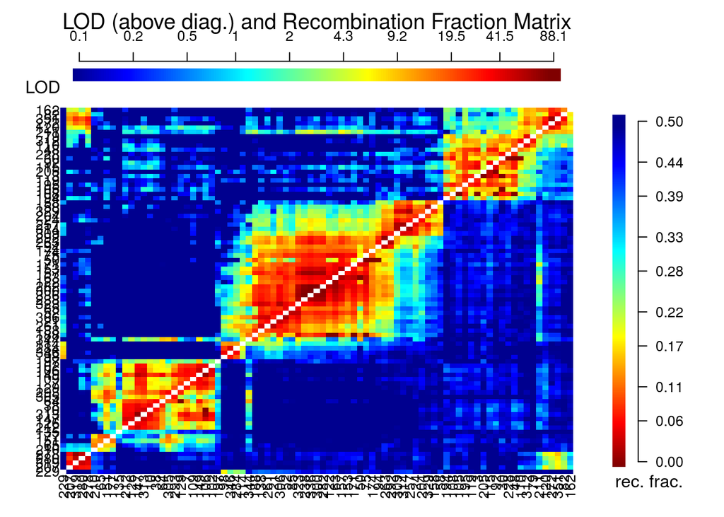

```r
rf_graph_table(LGs.HMM.force[[3]], scale = 1.8,
               inter = FALSE)
```

```r
## Do primeiro conjunto
# Do marcador 210 até o 197
seq1 <- LGs.HMM.force[[3]]$seq.num[1:26]
names_seq1 <- colnames(data1$geno)[seq1]

comp <- list()
for (i in 1:length(ref)){
  comp[[i]] <- ref[[i]] %in% names_seq1
}

# Maioria no grupo 7
comp
```

```
## [[1]]
##  [1] FALSE FALSE FALSE FALSE FALSE FALSE FALSE FALSE FALSE FALSE FALSE
## [12] FALSE FALSE FALSE FALSE FALSE FALSE
##
## [[2]]
##  [1] FALSE FALSE FALSE FALSE FALSE FALSE FALSE FALSE FALSE FALSE FALSE
## [12] FALSE FALSE FALSE FALSE FALSE FALSE
##
## [[3]]
##  [1]  TRUE FALSE FALSE FALSE FALSE FALSE FALSE FALSE FALSE FALSE FALSE
## [12] FALSE FALSE FALSE FALSE FALSE FALSE
##
## [[4]]
##  [1] FALSE FALSE FALSE FALSE FALSE FALSE FALSE FALSE FALSE FALSE FALSE
## [12] FALSE FALSE FALSE FALSE FALSE FALSE
##
## [[5]]
##  [1] FALSE FALSE FALSE FALSE FALSE FALSE FALSE FALSE FALSE FALSE FALSE
## [12] FALSE FALSE FALSE FALSE FALSE FALSE
##
## [[6]]
##  [1] FALSE FALSE FALSE FALSE FALSE FALSE FALSE FALSE FALSE FALSE FALSE
## [12] FALSE FALSE FALSE FALSE FALSE FALSE
##
## [[7]]
##  [1]  TRUE FALSE  TRUE  TRUE FALSE  TRUE  TRUE  TRUE  TRUE FALSE FALSE
## [12] FALSE FALSE FALSE FALSE FALSE FALSE
##
## [[8]]
##  [1] FALSE FALSE FALSE FALSE FALSE FALSE FALSE FALSE FALSE FALSE FALSE
## [12] FALSE FALSE FALSE FALSE FALSE FALSE
##
## [[9]]
##  [1] FALSE FALSE FALSE FALSE FALSE FALSE FALSE FALSE FALSE FALSE FALSE
## [12] FALSE FALSE FALSE FALSE FALSE FALSE
##
## [[10]]
##  [1] FALSE  TRUE FALSE FALSE FALSE FALSE FALSE FALSE FALSE FALSE FALSE
## [12] FALSE FALSE FALSE FALSE FALSE FALSE
##
## [[11]]
##  [1] FALSE FALSE FALSE FALSE FALSE FALSE FALSE FALSE FALSE FALSE FALSE
## [12] FALSE FALSE FALSE FALSE FALSE FALSE
##
## [[12]]
##  [1] FALSE FALSE FALSE FALSE FALSE FALSE FALSE FALSE FALSE FALSE FALSE
## [12] FALSE FALSE FALSE FALSE FALSE FALSE
##
## [[13]]
##  [1] FALSE FALSE FALSE FALSE FALSE FALSE FALSE FALSE FALSE FALSE FALSE
## [12] FALSE FALSE FALSE FALSE FALSE FALSE
##
## [[14]]
##  [1] FALSE FALSE FALSE FALSE FALSE FALSE FALSE FALSE FALSE FALSE FALSE
## [12] FALSE FALSE FALSE FALSE FALSE FALSE
```

```r
## Do segundo conjunto 98 até o 58
seq2 <- LGs.HMM.force[[3]]$seq.num[27:62]

names_seq2 <- colnames(data1$geno)[seq2]

comp <- list()
for (i in 1:length(ref)){
  comp[[i]] <- ref[[i]] %in% names_seq2
}

# Todos no grupo 10
comp
```

```
## [[1]]
##  [1] FALSE FALSE FALSE FALSE FALSE FALSE FALSE FALSE FALSE FALSE FALSE
## [12] FALSE FALSE FALSE FALSE FALSE FALSE
##
## [[2]]
##  [1] FALSE FALSE FALSE FALSE FALSE FALSE FALSE FALSE FALSE FALSE FALSE
## [12] FALSE FALSE FALSE FALSE FALSE FALSE
##
## [[3]]
##  [1] FALSE FALSE FALSE FALSE FALSE FALSE FALSE FALSE FALSE FALSE FALSE
## [12] FALSE FALSE FALSE FALSE FALSE FALSE
##
## [[4]]
##  [1] FALSE FALSE FALSE FALSE FALSE FALSE FALSE FALSE FALSE FALSE FALSE
## [12] FALSE FALSE FALSE FALSE FALSE FALSE
##
## [[5]]
##  [1] FALSE FALSE FALSE FALSE FALSE FALSE FALSE FALSE FALSE FALSE FALSE
## [12] FALSE FALSE FALSE FALSE FALSE FALSE
##
## [[6]]
##  [1] FALSE FALSE FALSE FALSE FALSE FALSE FALSE FALSE FALSE FALSE FALSE
## [12] FALSE FALSE FALSE FALSE FALSE FALSE
##
## [[7]]
##  [1] FALSE FALSE FALSE FALSE FALSE FALSE FALSE FALSE FALSE FALSE FALSE
## [12] FALSE FALSE FALSE FALSE FALSE FALSE
##
## [[8]]
##  [1] FALSE FALSE FALSE FALSE FALSE FALSE FALSE FALSE FALSE FALSE FALSE
## [12] FALSE FALSE FALSE FALSE FALSE FALSE
##
## [[9]]
##  [1] FALSE FALSE FALSE FALSE FALSE FALSE FALSE FALSE FALSE FALSE FALSE
## [12] FALSE FALSE FALSE FALSE FALSE FALSE
##
## [[10]]
##  [1]  TRUE FALSE  TRUE FALSE  TRUE  TRUE  TRUE  TRUE  TRUE  TRUE  TRUE
## [12]  TRUE  TRUE  TRUE  TRUE FALSE FALSE
##
## [[11]]
##  [1] FALSE FALSE FALSE FALSE FALSE FALSE FALSE FALSE FALSE FALSE FALSE
## [12] FALSE FALSE FALSE FALSE FALSE FALSE
##
## [[12]]
##  [1] FALSE FALSE FALSE FALSE FALSE FALSE FALSE FALSE FALSE FALSE FALSE
## [12] FALSE FALSE FALSE FALSE FALSE FALSE
##
## [[13]]
##  [1] FALSE FALSE FALSE FALSE FALSE FALSE FALSE FALSE FALSE FALSE FALSE
## [12] FALSE FALSE FALSE FALSE FALSE FALSE
##
## [[14]]
##  [1] FALSE FALSE FALSE FALSE FALSE FALSE FALSE FALSE FALSE FALSE FALSE
## [12] FALSE FALSE FALSE FALSE FALSE FALSE
```

```r
## Do terceiro conjunto do 194 até o 162
seq3 <- LGs.HMM.force[[3]]$seq.num[63:83]

names_seq3 <- colnames(data1$geno)[seq3]

comp <- list()
for (i in 1:length(ref)){
  comp[[i]] <- ref[[i]] %in% names_seq3
}

# Todos no grupo 3
comp
```

```
## [[1]]
##  [1] FALSE FALSE FALSE FALSE FALSE FALSE FALSE FALSE FALSE FALSE FALSE
## [12] FALSE FALSE FALSE FALSE FALSE FALSE
##
## [[2]]
##  [1] FALSE FALSE FALSE FALSE FALSE FALSE FALSE FALSE FALSE FALSE FALSE
## [12] FALSE FALSE FALSE FALSE FALSE FALSE
##
## [[3]]
##  [1] FALSE  TRUE  TRUE  TRUE  TRUE  TRUE  TRUE  TRUE  TRUE  TRUE FALSE
## [12]  TRUE FALSE FALSE FALSE FALSE FALSE
##
## [[4]]
##  [1] FALSE FALSE FALSE FALSE FALSE FALSE FALSE FALSE FALSE FALSE FALSE
## [12] FALSE FALSE FALSE FALSE FALSE FALSE
##
## [[5]]
##  [1] FALSE FALSE FALSE FALSE FALSE FALSE FALSE FALSE FALSE FALSE FALSE
## [12] FALSE FALSE FALSE FALSE FALSE FALSE
##
## [[6]]
##  [1] FALSE FALSE FALSE FALSE FALSE FALSE FALSE FALSE FALSE FALSE FALSE
## [12] FALSE FALSE FALSE FALSE FALSE FALSE
##
## [[7]]
##  [1] FALSE FALSE FALSE FALSE FALSE FALSE FALSE FALSE FALSE FALSE FALSE
## [12] FALSE FALSE FALSE FALSE FALSE FALSE
##
## [[8]]
##  [1] FALSE FALSE FALSE FALSE FALSE FALSE FALSE FALSE FALSE FALSE FALSE
## [12] FALSE FALSE FALSE FALSE FALSE FALSE
##
## [[9]]
##  [1] FALSE FALSE FALSE FALSE FALSE FALSE FALSE FALSE FALSE FALSE FALSE
## [12] FALSE FALSE FALSE FALSE FALSE FALSE
##
## [[10]]
##  [1] FALSE FALSE FALSE FALSE FALSE FALSE FALSE FALSE FALSE FALSE FALSE
## [12] FALSE FALSE FALSE FALSE FALSE FALSE
##
## [[11]]
##  [1] FALSE FALSE FALSE FALSE FALSE FALSE FALSE FALSE FALSE FALSE FALSE
## [12] FALSE FALSE FALSE FALSE FALSE FALSE
##
## [[12]]
##  [1] FALSE FALSE FALSE FALSE FALSE FALSE FALSE FALSE FALSE FALSE FALSE
## [12] FALSE FALSE FALSE FALSE FALSE FALSE
##
## [[13]]
##  [1] FALSE FALSE FALSE FALSE FALSE FALSE FALSE FALSE FALSE FALSE FALSE
## [12] FALSE FALSE FALSE FALSE FALSE FALSE
##
## [[14]]
##  [1] FALSE FALSE FALSE FALSE FALSE FALSE FALSE FALSE FALSE FALSE FALSE
## [12] FALSE FALSE FALSE FALSE FALSE FALSE
```

Obsevamos que alguns marcadores do mapa publicado agora se alocaram melhor em outros grupos, mantemos a separaçao conforme o Heatmap.

# 5 Reordenando o grupo 3.1 referente ao 7 do mapa publicado

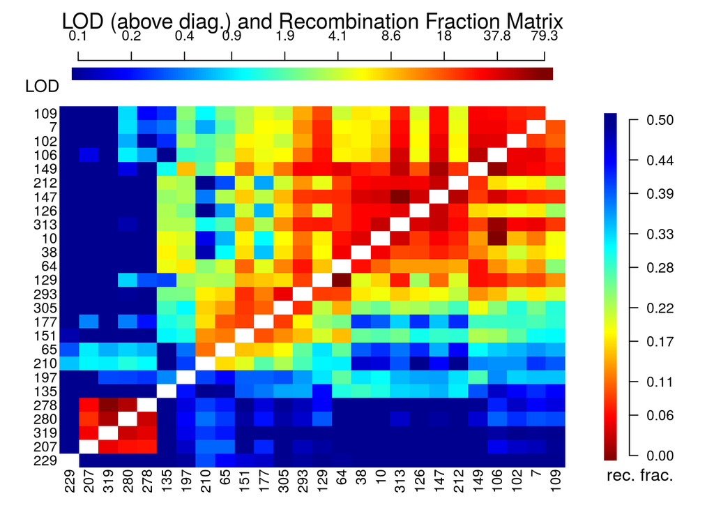

```r
mk_seq1 <- make_seq(rf2points,seq1)

LG3.1.ord <- order_seq(mk_seq1)
LG3.1.seq <- make_seq(LG3.1.ord, "force")

rf_graph_table(LG3.1.seq, scale = 2.2,
               inter = FALSE)
```

## 5.1 Removendo marcadores duvidosos

Conforme heatmap gerado pela cadeia de markov e as sugestões do comando “safe”, removemos alguns marcadores duvidosos do mapa na intenção de aprimorar o ordenamento.

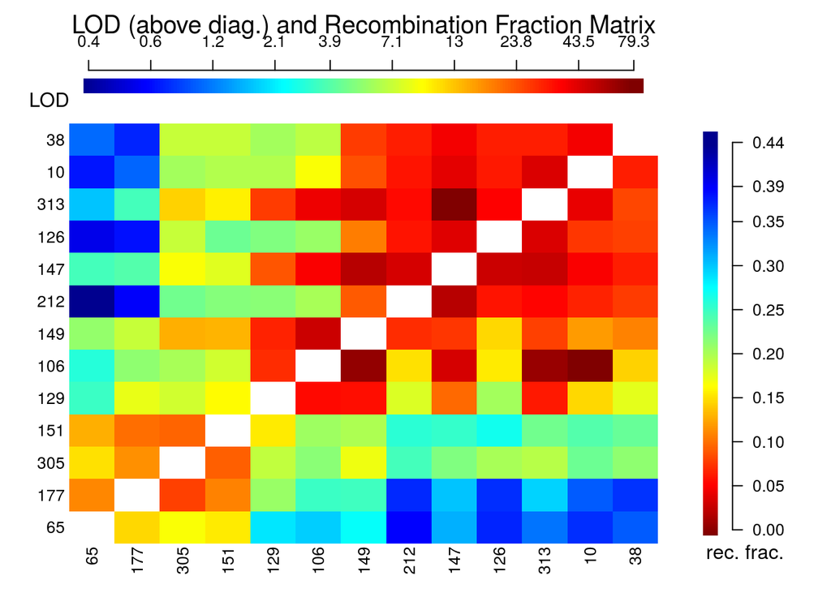

```r
Temp <- c(229, 135, 197, 278, 280, 319, 207, 210, 109, 102, 293, 64, 7)

Exc <- LG3.1.seq$seq.num %in% Temp

pos <- which(Exc == TRUE)

LG3.1.Exc <- LG3.1.seq$seq.num[-pos]

LG3.1 <- make_seq(rf2points, LG3.1.Exc)

LG3.1.ord <- order_seq(LG3.1, n.init = 5, THRES = 3,
                     touchdown = TRUE, draw.try = FALSE)


LG3.1.ord.seq <- make_seq(LG3.1.ord, "force")

rf_graph_table(LG3.1.ord.seq, scale = 2.2,
               inter = FALSE)
```

## 5.2 Inserindo novamente os marcadores

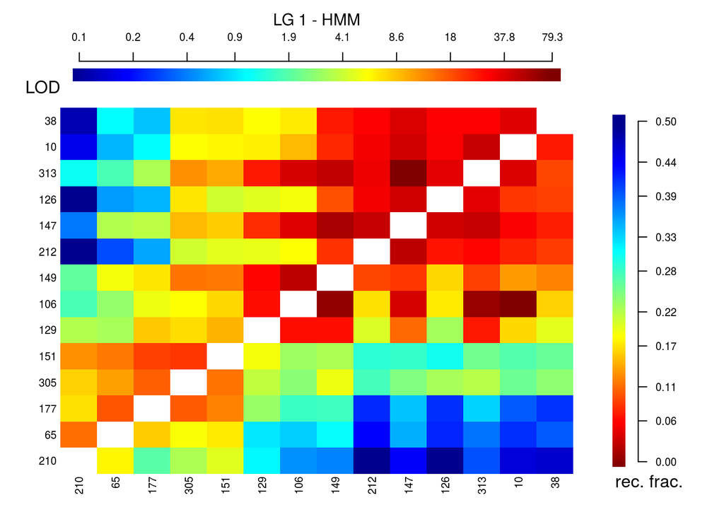

```r
Temp
Exten.LG3.1 <- try_seq(LG3.1.ord.seq, 210)

Exten.LG3.1

pos <- Exten.LG3.1$LOD == 0

pos <- which(pos == TRUE)

Check <- make_seq(Exten.LG3.1, pos)

LG3.1.ord.seq
Check

c(LG3.1.ord.seq$seq.like, Check$seq.like)

rf_graph_table(Check, scale = 1.5, main = paste("LG", 1, "- HMM"),
               inter = FALSE, axis.cex = 0.75)
```

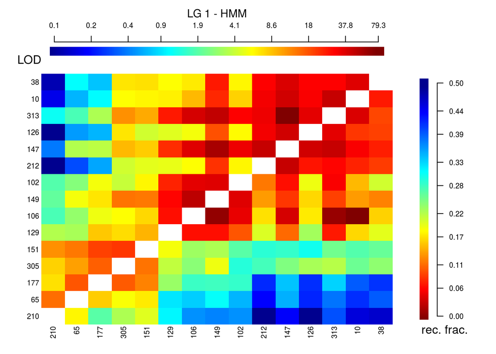

```r
LG3.1.exp <- make_seq(Exten.LG3.1, pos)

############

Temp
Exten.LG3.1 <- try_seq(LG3.1.exp,102)

Exten.LG3.1

pos <- Exten.LG3.1$LOD == 0

pos <- which(pos == TRUE)

Check <- make_seq(Exten.LG3.1, pos)

LG3.1.exp
Check

c(LG3.1.ord.seq$seq.like, Check$seq.like)

rf_graph_table(Check, scale = 1.5, main = paste("LG", 1, "- HMM"),
               inter = FALSE, axis.cex = 0.75)
```

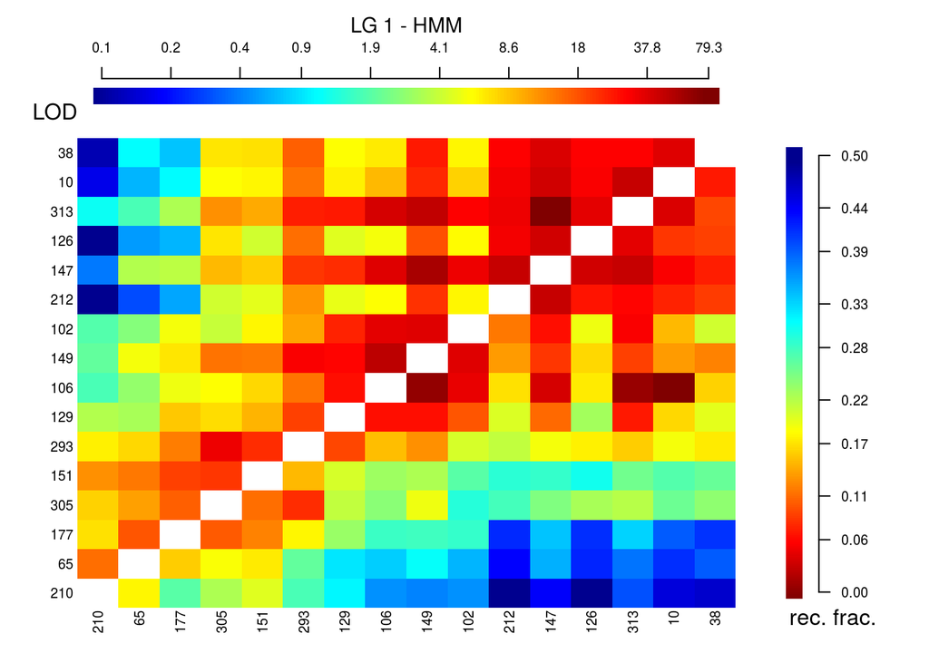

```r
LG3.1.exp <- make_seq(Exten.LG3.1, pos)

############

Temp
Exten.LG3.1 <- try_seq(LG3.1.exp,293)

Exten.LG3.1

pos <- Exten.LG3.1$LOD == 0

pos <- which(pos == TRUE)

Check <- make_seq(Exten.LG3.1, pos)

LG3.1.exp
Check

c(LG3.1.ord.seq$seq.like, Check$seq.like)

rf_graph_table(Check, scale = 1.5, main = paste("LG", 1, "- HMM"),
               inter = FALSE, axis.cex = 0.75)
```

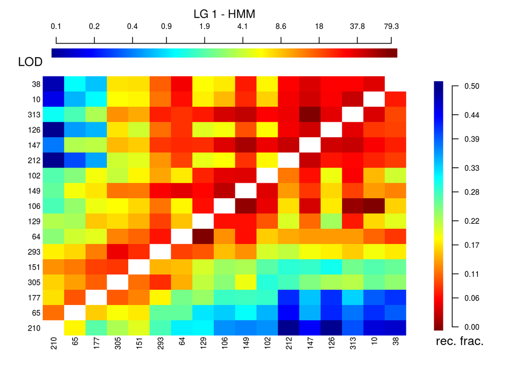

```r
LG3.1.exp <- make_seq(Exten.LG3.1, pos)

############

Temp
Exten.LG3.1 <- try_seq(LG3.1.exp,64)

Exten.LG3.1

pos <- Exten.LG3.1$LOD == 0

pos <- which(pos == TRUE)

Check <- make_seq(Exten.LG3.1, pos)

LG3.1.exp
Check

c(LG3.1.ord.seq$seq.like, Check$seq.like)

rf_graph_table(Check, scale = 1.5, main = paste("LG", 1, "- HMM"),
               inter = FALSE, axis.cex = 0.75)
```

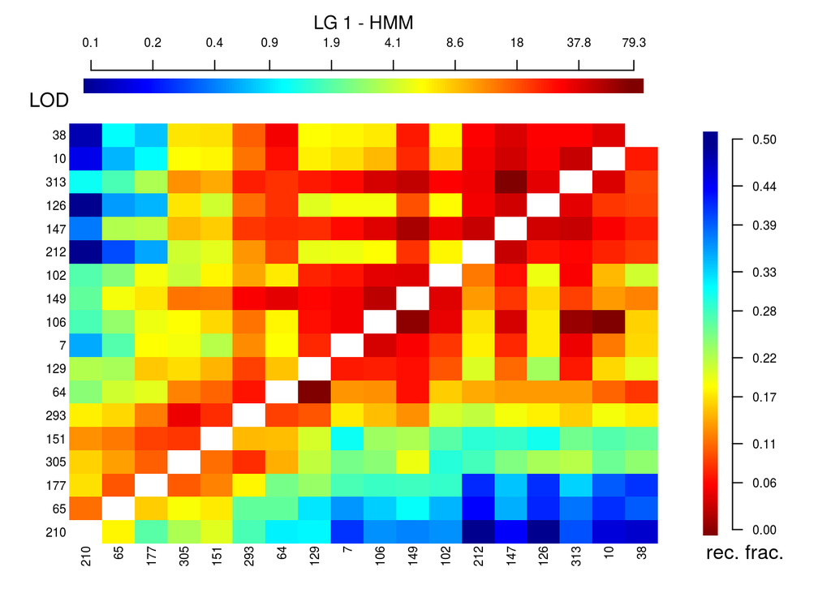

```r
LG3.1.exp <- make_seq(Exten.LG3.1, pos)


#################
Temp
Exten.LG3.1 <- try_seq(LG3.1.exp,7)

Exten.LG3.1

pos <- Exten.LG3.1$LOD == 0

pos <- which(pos == TRUE)

Check <- make_seq(Exten.LG3.1, pos)

LG3.1.exp
Check

c(LG3.1.ord.seq$seq.like, Check$seq.like)

rf_graph_table(Check, scale = 1.5, main = paste("LG", 1, "- HMM"),
               inter = FALSE, axis.cex = 0.75)
```

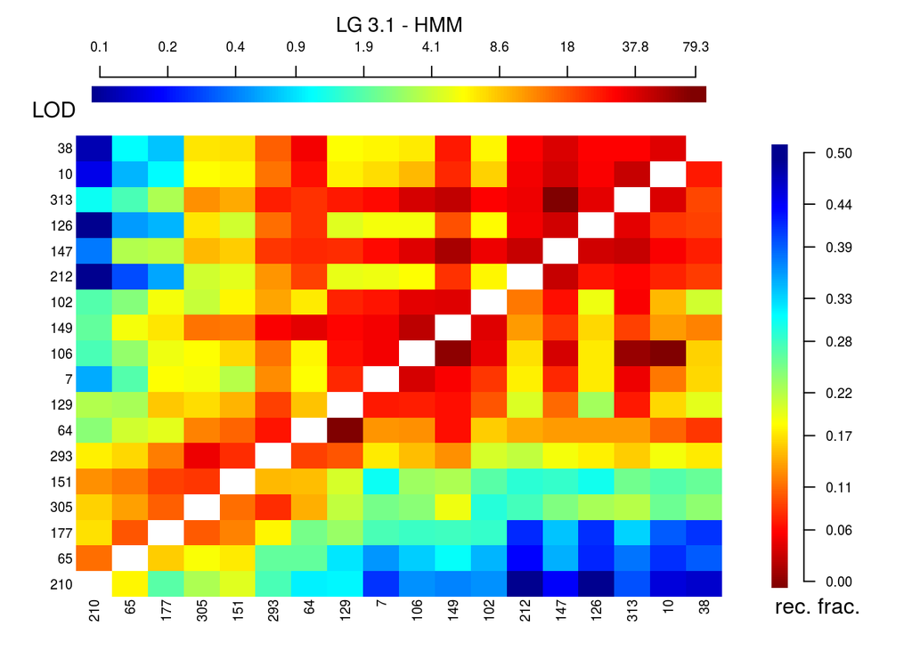

```r
LG3.1.exp <- make_seq(Exten.LG3.1, pos)


#################

LG3.1 <- LG3.1.exp

rf_graph_table(LG3.1, scale = 1.5, main = paste("LG", 3.1, "- HMM"),
               inter = FALSE, axis.cex = 0.75)
```

```r
save(LG3.1, file = "LG3.1.Rdata")

### Sobraram

comp <- seq1 %in% LG3.1.exp$seq.num
pos <- which(comp == FALSE)
trash.LG3 <- seq1[pos]
trash.LG3
```

```
## [1] 229 207 319 280 278 135 109 197
```

Ao serem inseridos no mapa, esses marcadores aumentavam o tamanho, diminuiam a verossimilhança e fugiam do padrão esperado no heatmap

# 6 Reordenando o grupo 3.2 referente ao 10 do mapa publicado

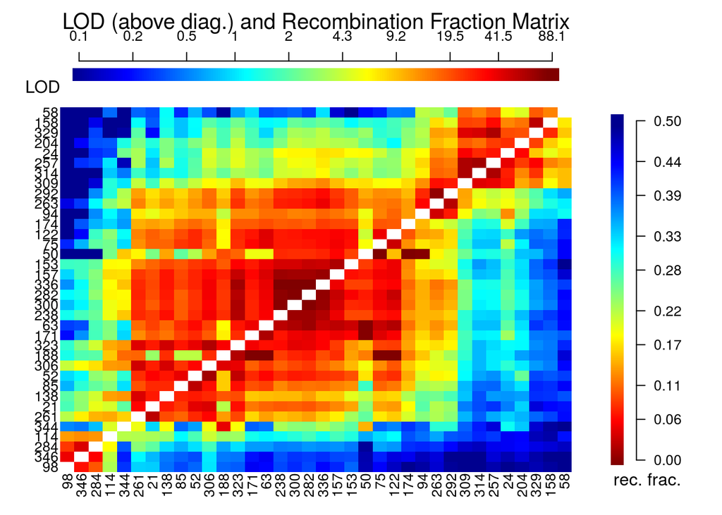

```r
mk_seq2 <- make_seq(rf2points,c(seq2))

LG3.2.ord <- order_seq(mk_seq2)
LG3.2.seq <- make_seq(LG3.2.ord, "force")

rf_graph_table(LG3.2.seq, scale = 2.2,
               inter = FALSE)
```

## 6.1 Removendo marcadores duvidosos

Conforme heatmap gerado pela cadeia de markov e as sugestões do comando “safe”, removemos alguns marcadores duvidosos do mapa na intenção de aprimorar o ordenamento.

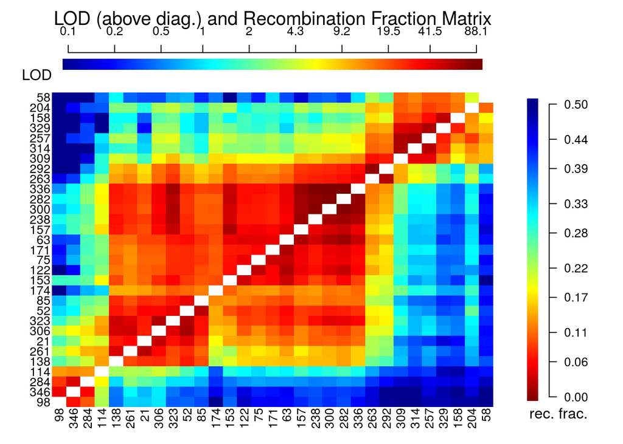

```r
Temp <- c(344, 188, 50,94,24)

Exc <- LG3.2.seq$seq.num %in% Temp

pos <- which(Exc == TRUE)

LG3.2.Exc <- LG3.2.seq$seq.num[-pos]

LG3.2 <- make_seq(rf2points, LG3.2.Exc)

LG3.2.ord <- order_seq(LG3.2, n.init = 5, THRES = 3,
                       touchdown = TRUE, draw.try = FALSE)


LG3.2.ord.seq <- make_seq(LG3.2.ord, "force")

rf_graph_table(LG3.2.ord.seq, scale = 2.2,
               inter = FALSE)
```

## 6.2 Inserindo novamente os marcadores

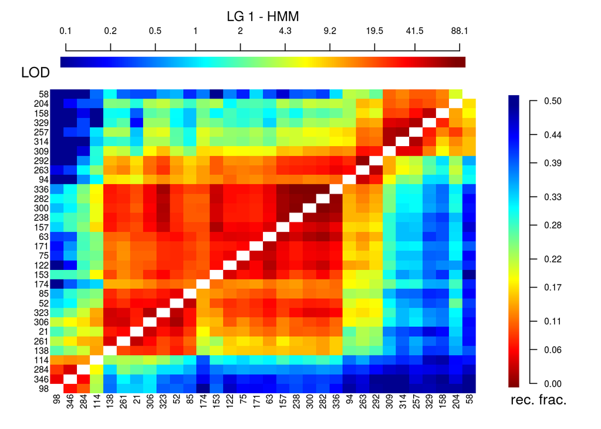

```r
Temp
Exten.LG3.2 <- try_seq(LG3.2.ord.seq, 94)

Exten.LG3.2

pos <- Exten.LG3.2$LOD == 0

pos <- which(pos == TRUE)

Check <- make_seq(Exten.LG3.2, pos)

LG3.2.ord.seq
Check

c(LG3.2.ord.seq$seq.like, Check$seq.like)

rf_graph_table(Check, scale = 1.5, main = paste("LG", 1, "- HMM"),
               inter = FALSE, axis.cex = 0.75)
```

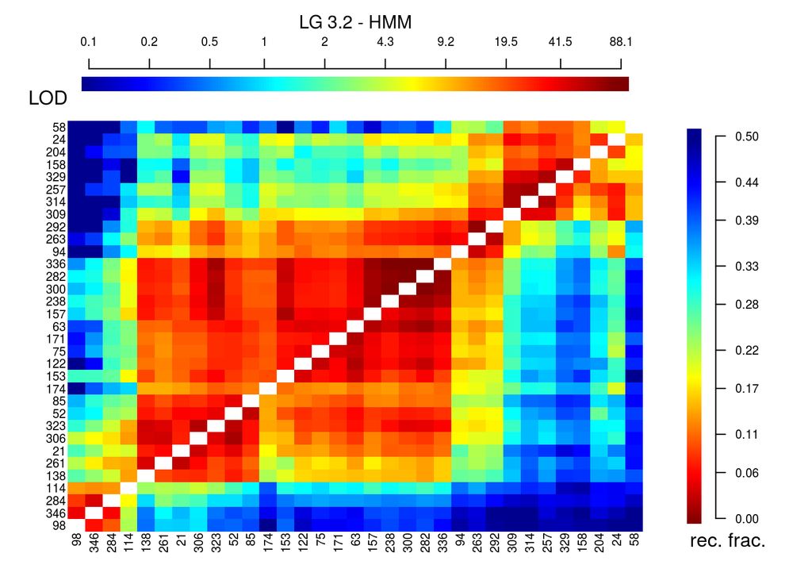

```r
LG3.2.exp <- make_seq(Exten.LG3.2, pos)

################
Temp

Exten.LG3.2 <- try_seq(LG3.2.exp, 24)

Exten.LG3.2

pos <- Exten.LG3.2$LOD == 0

pos <- which(pos == TRUE)

Check <- make_seq(Exten.LG3.2, pos)

LG3.2.exp
Check

c(LG3.2.ord.seq$seq.like, Check$seq.like)


# Se for realmente adicionar o marcador, tirar o comentário
LG3.2.exp <- make_seq(Exten.LG3.2, pos)

LG3.2 <- LG3.2.exp

rf_graph_table(LG3.2, scale = 1.5, main = paste("LG", 3.2, "- HMM"),
               inter = FALSE, axis.cex = 0.75)
```

```r
save(LG3.2, file = "LG3.2.Rdata")

##### Sobraram:
comp <- seq2 %in% LG3.2.exp$seq.num
pos <- which(comp == FALSE)
trash.LG3 <- seq2[pos]
trash.LG3
```

```
## [1] 344 188  50
```

Ao serem inseridos no mapa, esses marcadores aumentavam o tamanho, diminuiam a verossimilhança e fugiam do padrão esperado no heatmap.

# 7 Reordenando o grupo 3.3 referente ao 3 do mapa publicado

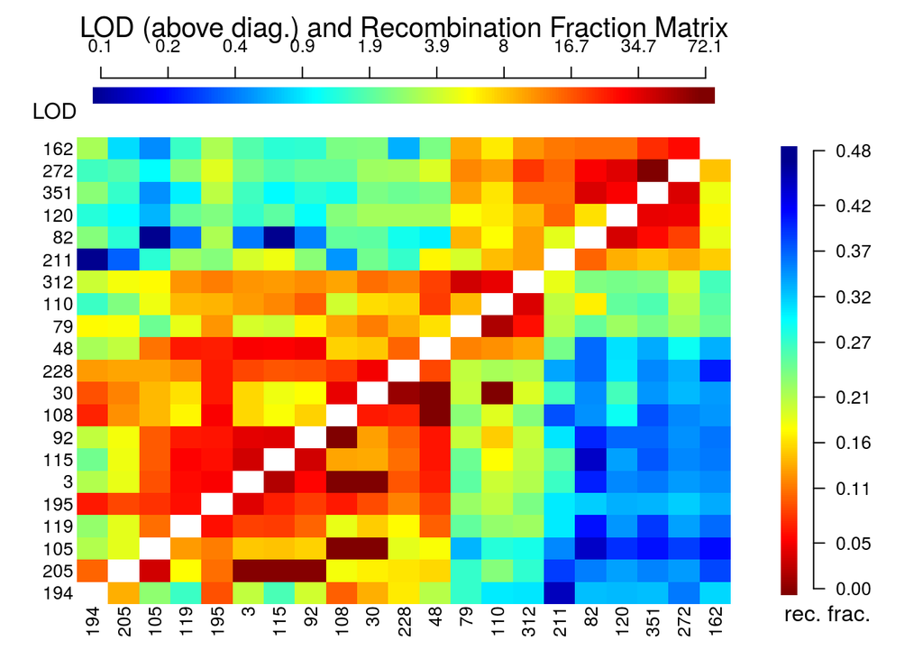

```r
mk_seq3 <- make_seq(rf2points,seq3)

LG3.3.ord <- order_seq(mk_seq3)
LG3.3.seq <- make_seq(LG3.3.ord, "force")

rf_graph_table(LG3.3.seq, scale = 2.2,
               inter = FALSE)
```

## 7.1 Removendo marcadores duvidosos

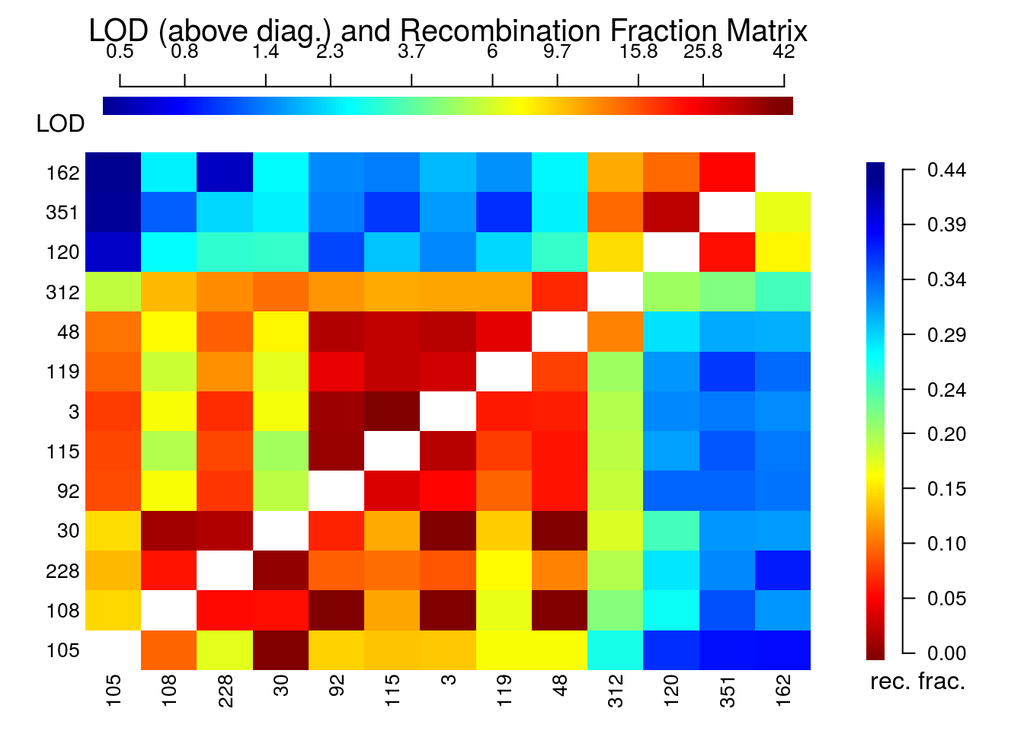

```r
Temp <- c(211, 82, 194, 79, 110, 272, 195, 205)

Exc <- LG3.3.seq$seq.num %in% Temp

pos <- which(Exc == TRUE)

LG3.3.Exc <- LG3.3.seq$seq.num[-pos]

LG3.3 <- make_seq(rf2points, LG3.3.Exc)

LG3.3.ord <- order_seq(LG3.3, n.init = 5, THRES = 3,
                       touchdown = TRUE, draw.try = FALSE)


LG3.3.ord.seq <- make_seq(LG3.3.ord, "force")

rf_graph_table(LG3.3.ord.seq, scale = 2.2,
               inter = FALSE)
```

```r
LG3.3 <- LG3.3.ord.seq
```

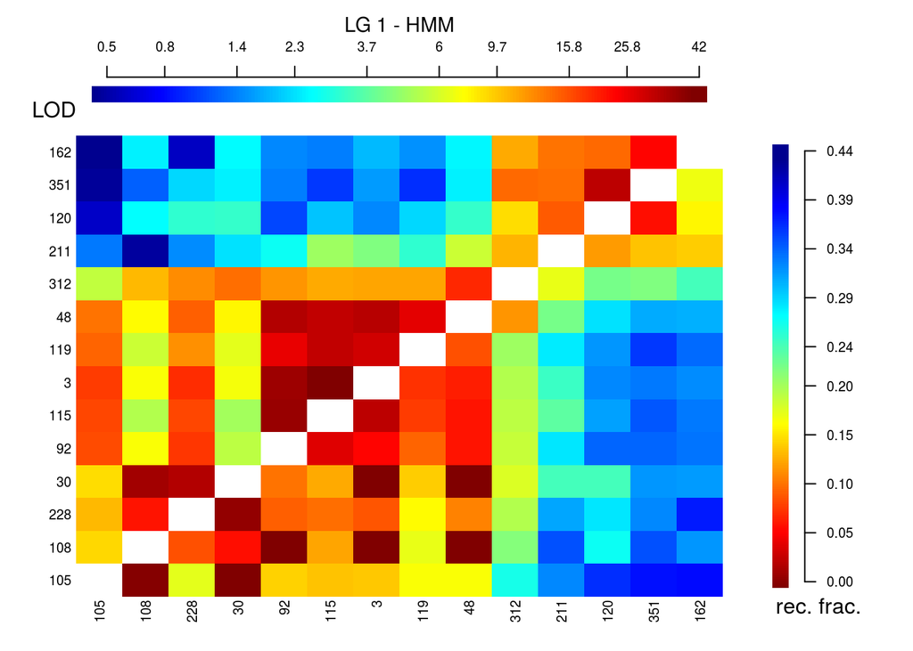

```r
Temp
Exten.LG3.3 <- try_seq(LG3.3.ord.seq, 211)

Exten.LG3.3

pos <- Exten.LG3.3$LOD == 0

pos <- which(pos == TRUE)

Check <- make_seq(Exten.LG3.3, pos)

LG3.3.ord.seq
Check

c(LG3.3.ord.seq$seq.like, Check$seq.like)

rf_graph_table(Check, scale = 1.5, main = paste("LG", 1, "- HMM"),
               inter = FALSE, axis.cex = 0.75)
```

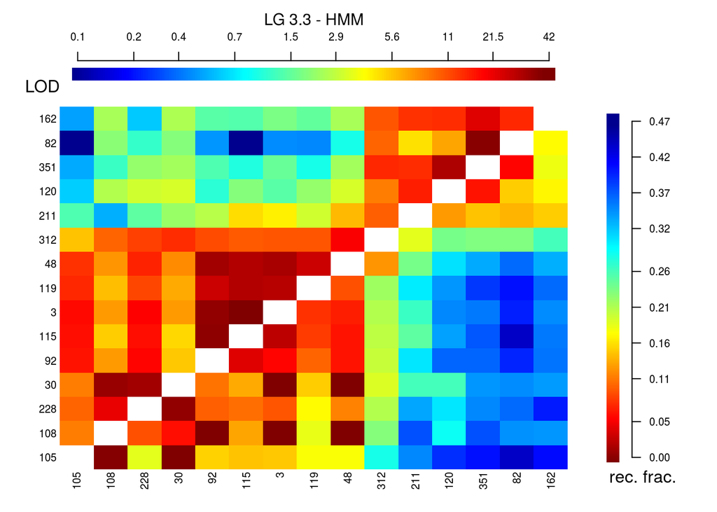

```r
LG3.3.exp <- make_seq(Exten.LG3.3, pos)

################
Temp

Exten.LG3.3 <- try_seq(LG3.3.exp, 82)

Exten.LG3.3

pos <- Exten.LG3.3$LOD == 0

pos <- which(pos == TRUE)

Check <- make_seq(Exten.LG3.3, pos)

LG3.3.exp
Check

c(LG3.3.ord.seq$seq.like, Check$seq.like)


rf_graph_table(Check, scale = 1.5, main = paste("LG", 3.3, "- HMM"),
               inter = FALSE, axis.cex = 0.75)
```

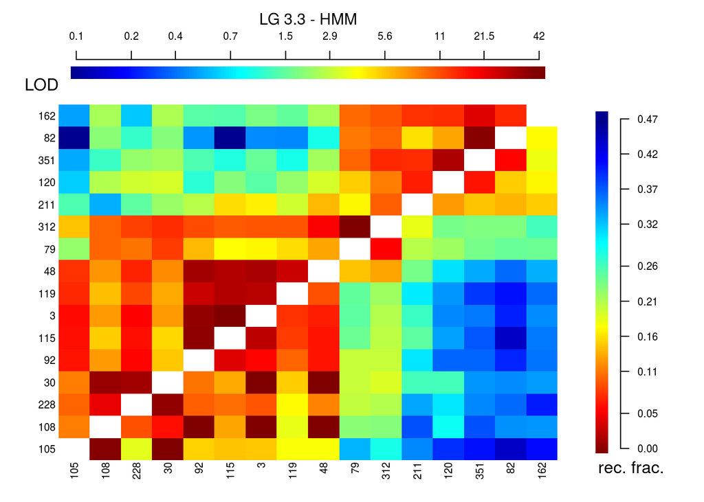

```r
LG3.3.exp <- make_seq(Exten.LG3.3, pos)


################
Temp

Exten.LG3.3 <- try_seq(LG3.3.exp, 79)

Exten.LG3.3

pos <- Exten.LG3.3$LOD == 0

pos <- which(pos == TRUE)

Check <- make_seq(Exten.LG3.3, pos)

LG3.3.exp
Check

c(LG3.3.ord.seq$seq.like, Check$seq.like)


rf_graph_table(Check, scale = 1.5, main = paste("LG", 3.3, "- HMM"),
               inter = FALSE, axis.cex = 0.75)
```

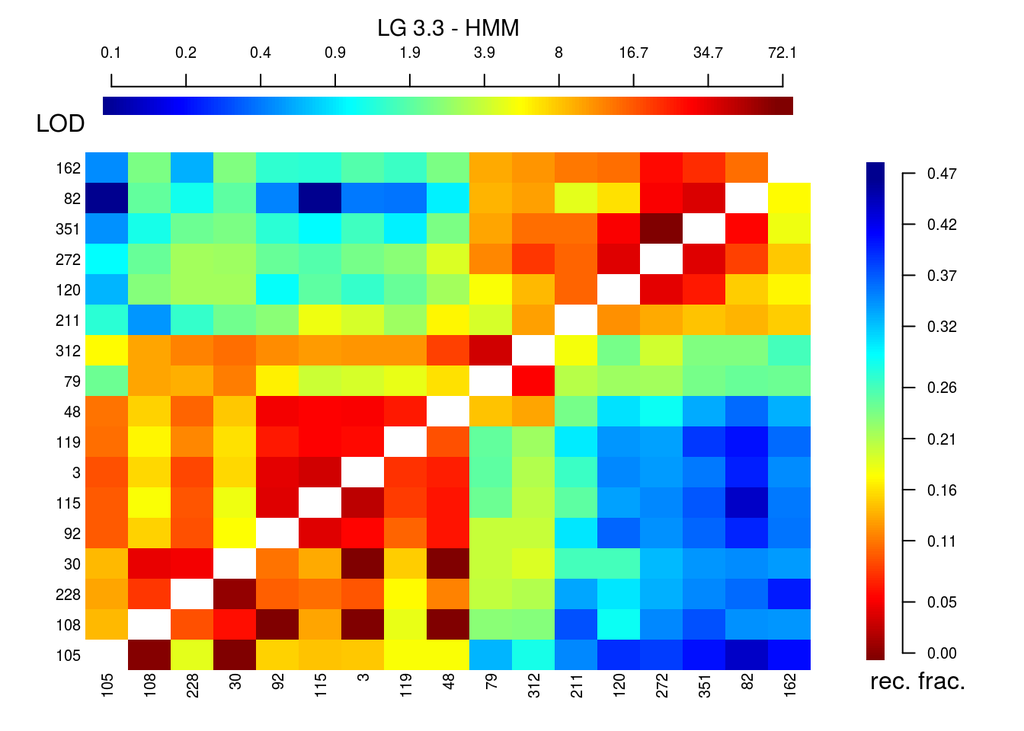

```r
LG3.3.exp <- make_seq(Exten.LG3.3, pos)

################
Temp

Exten.LG3.3 <- try_seq(LG3.3.exp, 272)

Exten.LG3.3

pos <- Exten.LG3.3$LOD == 0

pos <- which(pos == TRUE)

Check <- make_seq(Exten.LG3.3, pos)

LG3.3.exp
Check

c(LG3.3.ord.seq$seq.like, Check$seq.like)


LG3.3.exp <- make_seq(Exten.LG3.3, pos)

LG3.3 <- LG3.3.exp

rf_graph_table(LG3.3, scale = 1.5, main = paste("LG", 3.3, "- HMM"),
               inter = FALSE, axis.cex = 0.75)
```

```r
save(LG3.3, file = "LG3.3.Rdata")

##### Sobraram:
comp <- seq3 %in% LG3.3.exp$seq.num
pos <- which(comp == FALSE)
trash.LG3 <- seq3[pos]
trash.LG3
```

```
## [1] 194 195 205 110
```